# Methylation platform harmonization and batch-effect assessment

# Scope

This notebook documents how the methylation batch effect was identified and corrected. TCGA methylation data generated with the Illumina HumanMethylation27 and HumanMethylation450 platforms were harmonized, and the effect of BMIQ normalization was assessed using probe-design distributions and the LAML platform comparison shown in Supplementary Figure 6.

LAML was the only tumor type for which the same 194 samples were profiled on both the 27K and 450K platforms. This paired setting allowed the platform effect to be evaluated without differences in sample composition. LAML was therefore reserved for this validation and was not included in the downstream harmonized methylation matrix.

The complete normalization workflow is computationally intensive. The reduced checkpoint needed for Supplementary Figure 6 is included in `data/processed/`.

# R packages

```r
library(curatedTCGAData)
library(TCGAutils)
library(MultiAssayExperiment)
library(minfi)
library(IlluminaHumanMethylation450kanno.ilmn12.hg19)
library(RPMM)
library(dplyr)
library(reshape2)
library(ggplot2)
library(ggpubr)
library(cowplot)
```

# TCGA methylation data

```r
assay_type <- c("Methylation*")
vetS4_meth_2_1_1 <- curatedTCGAData(
  diseaseCode = "*",
  assays = assay_type,
  version = "2.1.1",
  dry.run = FALSE
)
primaryTumors1 <- TCGAprimaryTumors(vetS4_meth_2_1_1)
```

# Platform-specific sample preparation

Outside LAML, samples measured on both platforms were retained from the 450K platform and removed from the corresponding 27K dataset. LAML was handled separately as the paired platform-control dataset.

```r
j <- grep(
  "^(?!LAML).{2,5}_Methylation_methyl27-\\d{8}$",
  names(primaryTumors1@ExperimentList@listData),
  perl = TRUE
)
vet <- sub(
  "^(.*?)_.*",
  "\\1",
  grep(
    "^(?!LAML).{2,5}_Methylation_methyl27-\\d{8}$",
    names(primaryTumors1@ExperimentList@listData),
    value = TRUE,
    perl = TRUE
  )
)

meth_data_27 <- list()
meth_data_450 <- list()
for (i in 1:length(vet)) {
  meth_data_27[[vet[i]]] <- as.data.frame(assay(primaryTumors1, j[i]))
  meth_data_450[[vet[i]]] <- as.data.frame(
    assay(primaryTumors1, (j + 1)[i])
  )
}

campioni_comuni_piattaforme <- function(meth_data_450, meth_data_27) {
  risultati <- list()
  for (i in 1:length(meth_data_450)) {
    col_comuni <- intersect(
      substr(names(meth_data_27[[i]]), 1, 12),
      substr(names(meth_data_450[[i]]), 1, 12)
    )
    risultati[[vet[i]]] <- col_comuni
  }
  return(risultati)
}

risultati <- campioni_comuni_piattaforme(meth_data_450, meth_data_27)

rimuovi_colonne <- function(meth_data_27, risultati) {
  for (i in 1:length(meth_data_27)) {
    if (length(risultati[[i]]) > 0) {
      colonne_da_rimuovere <- risultati[[i]]
      meth_data_27[[i]] <- meth_data_27[[i]][
        ,
        !substr(names(meth_data_27[[i]]), 1, 12) %in% colonne_da_rimuovere
      ]
    }
  }
  return(meth_data_27)
}

meth_data_27_aggiornato <- rimuovi_colonne(meth_data_27, risultati)

j <- c(
  grep(
    "^(?!LAML).{2,5}_Methylation_methyl450-\\d{8}$",
    names(primaryTumors1@ExperimentList@listData),
    perl = TRUE
  ),
  grep(
    "^.{3,5}_Methylation-\\d{8}$",
    names(primaryTumors1@ExperimentList@listData)
  )
)
j <- j[order(j)]

vet <- c(
  sub(
    "^(.*?)_.*",
    "\\1",
    grep(
      "^(?!LAML).{2,5}_Methylation_methyl450-\\d{8}$",
      names(primaryTumors1@ExperimentList@listData),
      value = TRUE,
      perl = TRUE
    )
  ),
  sub(
    "^(.*?)_.*",
    "\\1",
    grep(
      "^.{3,5}_Methylation-\\d{8}$",
      names(primaryTumors1@ExperimentList@listData),
      value = TRUE
    )
  )
)
vet <- vet[order(vet)]

meth_450_finale <- list()
for (i in 1:length(vet)) {
  meth_450_finale[[vet[i]]] <- as.data.frame(assay(primaryTumors1, j[i]))
}
```

# Identification of the 450K probe-design bias

The beta-value distributions of Infinium type-I and type-II probes were compared within each tumor type. Their displaced distributions identified the probe-design bias in the unnormalized 450K data. The resulting diagnostic plots are retained in `Methylation_batch_ correction_result/plot_bias/`.

```r
data("IlluminaHumanMethylation450kanno.ilmn12.hg19")
probeInfo450_IlluminaI <- getAnnotation(
  IlluminaHumanMethylation450kanno.ilmn12.hg19
)
probe <- as.data.frame(cbind(
  CpG = probeInfo450_IlluminaI@listData$Name,
  type = probeInfo450_IlluminaI@listData$Type
))
probe_I <- probe %>% filter(type == "I")
probe_II <- probe %>% filter(type == "II")

for (i in 1:length(vet)) {
  tmp_I <- intersect(rownames(meth_450_finale[[i]]), probe_I$CpG)
  tmp_II <- intersect(rownames(meth_450_finale[[i]]), probe_II$CpG)

  flag <- meth_450_finale[[i]][tmp_I, , drop = FALSE]
  flag <- as.data.frame(t(flag))
  flag1 <- meth_450_finale[[i]][tmp_II, , drop = FALSE]
  flag1 <- as.data.frame(t(flag1))

  flag <- flag %>%
    mutate(platform = "I") %>%
    relocate(platform)
  flag1 <- flag1 %>%
    mutate(platform = "II") %>%
    relocate(platform)

  prova <- melt(
    flag,
    id.vars = "platform",
    variable.name = "gene",
    value.name = "metilazione",
    na.rm = TRUE
  )
  prova1 <- melt(
    flag1,
    id.vars = "platform",
    variable.name = "gene",
    value.name = "metilazione",
    na.rm = TRUE
  )
  prova2 <- rbind(prova, prova1)

  a <- ggplot(prova2, aes(x = metilazione, color = platform)) +
    geom_density(alpha = .5) +
    ggtitle(vet[[i]])
  a
}
```

# BMIQ correction of 450K data

The unchanged BMIQ v1.3 implementation described by Teschendorff et al. was used to correct the Infinium type-II probe-design bias. The implementation uses `RPMM` and was run independently for every sample with the parameters shown below.

```r
data_finale <- list()
for (i in 1:length(vet)) {
  mat <- meth_450_finale[[i]]
  ind <- rowSums(is.na(mat)) == ncol(mat)
  mat <- mat[!ind, ]

  mat <- mat %>%
    mutate(
      type = case_when(
        rownames(mat) %in% probe_I$CpG ~ "1",
        rownames(mat) %in% probe_II$CpG ~ "2"
      )
    ) %>%
    relocate(type) %>%
    filter(!grepl("^rs", rownames(.)))

  sample <- as.vector(substr(colnames(mat[-1]), 1, 12))
  result <- list()
  betas <- list()

  for (k in 2:ncol(mat)) {
    beta.v <- as.vector(mat[, k])
    design.v <- as.vector(mat$type)
    samp <- sample[k - 1]
    result[[sample[k - 1]]] <- BMIQ(
      beta.v,
      design.v,
      nL = 3,
      doH = TRUE,
      nfit = 50000,
      th1.v = c(0.2, 0.75),
      th2.v = NULL,
      niter = 5,
      tol = 0.001,
      plots = FALSE,
      sampleID = samp
    )
    ttt <- data.frame(
      type = design.v,
      beta = result[[k - 1]][[1]],
      row.names = rownames(mat)
    )
    colnames(ttt)[2] <- samp
    betas[[sample[k - 1]]] <- ttt
  }

  col_list <- lapply(betas[-1], function(x) x[, 2])
  finale <- data.frame(
    betas[[1]],
    do.call(cbind, col_list),
    row.names = rownames(betas[[1]])
  )
  colnames(finale) <- gsub("\\.", "-", colnames(finale))
  data_finale[[vet[i]]] <- finale

  flag <- finale %>%
    filter(type == "1")
  flag1 <- finale %>%
    filter(type == "2")

  prova <- melt(
    flag,
    id.vars = "type",
    variable.name = "gene",
    value.name = "metilazione",
    na.rm = TRUE
  )
  prova1 <- melt(
    flag1,
    id.vars = "type",
    variable.name = "gene",
    value.name = "metilazione",
    na.rm = TRUE
  )
  prova2 <- rbind(prova, prova1)

  a <- ggplot(prova2, aes(x = metilazione, color = type)) +
    geom_density(alpha = .5) +
    ggtitle(vet[[i]]) +
    xlab("beta value") +
    labs(color = "probe types")
  a
}
```

The post-BMIQ density plots used to verify the correction are retained in `Methylation_batch_ correction_result/plot_BMIQ_overall/`.

# Platform harmonization

Probes containing SNPs at the CpG interrogation or single-base extension positions were removed. The 27K data were converted to the 450K representation, and only CpGs shared by the two platforms were retained.

```r
minfi_450 <- list()
final_beta_450 <- list()
vet <- names(data_finale)
for (i in 1:length(data_finale)) {
  formato_450k <- makeGenomicRatioSetFromMatrix(
    as.matrix(data_finale[[i]]),
    array = "IlluminaHumanMethylation450k",
    annotation = "ilmn12.hg19"
  )
  gset <- addSnpInfo(formato_450k)
  minfi_450[[vet[i]]] <- dropLociWithSnps(
    gset,
    snps = c("SBE", "CpG"),
    maf = 0
  )
  final_beta_450[[vet[i]]] <- as.data.frame(getBeta(minfi_450[[i]]))
  final_beta_450[[i]][, -1] <- lapply(
    final_beta_450[[i]][, -1],
    as.numeric
  )
}

vet <- names(meth_data_27_aggiornato)
converted_27 <- list()
final_beta_27 <- list()
for (i in 1:length(meth_data_27_aggiornato)) {
  ind <- rowSums(is.na(meth_data_27_aggiornato[[i]])) ==
    ncol(meth_data_27_aggiornato[[i]])
  meth_data_27_aggiornato[[i]] <- meth_data_27_aggiornato[[i]][!ind, ]

  formato_27k <- makeGenomicRatioSetFromMatrix(
    as.matrix(meth_data_27_aggiornato[[i]]),
    array = "IlluminaHumanMethylation27k",
    annotation = "ilmn12.hg19"
  )
  converted <- convertArray(
    formato_27k,
    outType = "IlluminaHumanMethylation450k"
  )
  gset <- addSnpInfo(converted)
  converted_27[[vet[i]]] <- dropLociWithSnps(
    gset,
    snps = c("SBE", "CpG"),
    maf = 0
  )
  final_beta_27[[vet[i]]] <- as.data.frame(getBeta(converted_27[[i]]))
  colnames(final_beta_27[[vet[i]]]) <- substr(
    colnames(final_beta_27[[vet[i]]]),
    1,
    12
  )
}

cpg_comuni_piattaforme <- function(meth_data_450, meth_data_27) {
  risultati_450 <- list()
  risultati_27 <- list()
  cpg_comuni <- intersect(
    rownames(meth_data_27[[1]]),
    rownames(meth_data_450[[1]])
  )
  risultati_27 <- lapply(
    meth_data_27,
    function(x) x[cpg_comuni, , drop = FALSE]
  )
  risultati_450 <- lapply(
    meth_data_450,
    function(x) x[cpg_comuni, , drop = FALSE]
  )
  return(list(
    risultati_27 = risultati_27,
    risultati_450 = risultati_450
  ))
}

risultati <- cpg_comuni_piattaforme(final_beta_450, final_beta_27)
```

# Gene-level methylation matrices

```r
risultati_450 <- risultati[[2]]
vet <- names(risultati_450)
genes <- data.frame(
  mcols(primaryTumors1[["ACC_Methylation-20160128"]])
)

GS_450 <- list()
for (i in 1:length(risultati_450)) {
  tmp <- intersect(rownames(risultati_450[[1]]), rownames(genes))
  flag <- genes[tmp, , drop = FALSE]

  risultati_450[[i]] <- risultati_450[[i]][, -1] %>%
    mutate(Gene_Symbol = flag$Gene_Symbol) %>%
    relocate(Gene_Symbol)

  gene_list <- list(risultati_450[[i]]$Gene_Symbol)
  GS_450[[vet[i]]] <- aggregate(
    risultati_450[[i]][, -1],
    by = gene_list,
    FUN = "mean",
    na.rm = TRUE
  )
  rownames(GS_450[[i]]) <- GS_450[[i]]$Group.1
  GS_450[[i]] <- as.data.frame(t(
    GS_450[[i]][, 2:ncol(GS_450[[i]])]
  ))
}

risultati_27 <- risultati[[1]]
vet <- names(risultati_27)
genes <- data.frame(
  mcols(primaryTumors1[["BRCA_Methylation_methyl27-20160128"]])
)

GS_27 <- list()
for (i in 1:length(risultati_27)) {
  tmp <- intersect(rownames(risultati_27[[1]]), rownames(genes))
  flag <- genes[tmp, , drop = FALSE]

  risultati_27[[i]] <- risultati_27[[i]] %>%
    mutate(Gene_Symbol = flag$Gene_Symbol) %>%
    relocate(Gene_Symbol)

  gene_list <- list(risultati_27[[i]]$Gene_Symbol)
  GS_27[[vet[i]]] <- aggregate(
    risultati_27[[i]][, -1],
    by = gene_list,
    FUN = "mean",
    na.rm = TRUE
  )
  rownames(GS_27[[i]]) <- GS_27[[i]]$Group.1
  GS_27[[i]] <- as.data.frame(t(
    GS_27[[i]][, 2:ncol(GS_27[[i]])]
  ))
  rownames(GS_27[[i]]) <- substr(rownames(GS_27[[i]]), 1, 12)
}

merge_common_data <- function(HM_27, HM_450) {
  common_names <- intersect(names(HM_450), names(HM_27))
  merged_list <- list()
  for (name in common_names) {
    merged_list[[name]] <- rbind(HM_450[[name]], HM_27[[name]])
  }
  for (name in setdiff(names(HM_450), common_names)) {
    merged_list[[name]] <- HM_450[[name]]
  }
  return(merged_list)
}

finale_meth <- merge_common_data(GS_27, GS_450)
finale_meth <- finale_meth[order(names(finale_meth))]
```

# Supplementary Figure 6

The reduced checkpoint contains only the normalized LAML 450K matrix and the raw LAML matrices from the 27K and 450K platforms. The PCA and beta-value distributions compare the same 194 samples, showing the platform effect before normalization and its reduction after BMIQ correction.

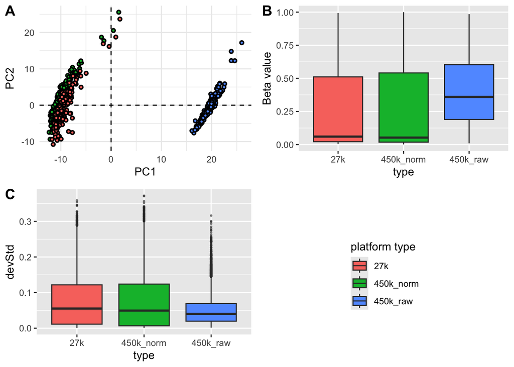

```r
library(dplyr)
library(reshape2)
library(ggplot2)
library(ggpubr)
library(cowplot)
load("../data/processed/methylation_batch_effect_data.RData")

tmp <- intersect(colnames(laml_450_norm), colnames(gene_450_raw))
laml_450_raw <- gene_450_raw[, tmp, drop = FALSE]
laml_27_raw <- gene_27_raw[, tmp, drop = FALSE]

flag <- laml_450_norm %>%
  mutate(type = "450k_norm") %>%
  relocate(type)

flag1 <- laml_27_raw %>%
  mutate(type = "27k") %>%
  relocate(type)

flag3 <- laml_450_raw %>%
  mutate(type = "450k_raw") %>%
  relocate(type)

prova <- melt(
  flag,
  id.vars = "type",
  variable.name = "gene",
  value.name = "metilazione"
)
prova1 <- melt(
  flag1,
  id.vars = "type",
  variable.name = "gene",
  value.name = "metilazione"
)
prova2 <- melt(
  flag3,
  id.vars = "type",
  variable.name = "gene",
  value.name = "metilazione"
)
fin <- rbind(prova, prova1)
fin1 <- rbind(fin, prova2)

sd <- as.data.frame(apply(flag[, -1], 2, sd, na.rm = TRUE))
sd <- sd %>%
  mutate(type = "450k_norm") %>%
  relocate(type)
colnames(sd)[2] <- "devStd"

sd1 <- as.data.frame(apply(flag1[, -1], 2, sd, na.rm = TRUE))
sd1 <- sd1 %>%
  mutate(type = "27k") %>%
  relocate(type)
colnames(sd1)[2] <- "devStd"

sd2 <- as.data.frame(apply(flag3[, -1], 2, sd, na.rm = TRUE))
sd2 <- sd2 %>%
  mutate(type = "450k_raw") %>%
  relocate(type)
colnames(sd2)[2] <- "devStd"

fina <- rbind(sd, sd1)
fina1 <- rbind(fina, sd2)

test <- rbind(flag, flag1)
test <- rbind(test, flag3)
test1 <- t(test[, -1])
test1 <- na.omit(test1)
test2 <- as.data.frame(t(test1))
test2 <- cbind(type = test[, 1], test2)

pca_result <- prcomp(test2[, -1], scale = FALSE)
pca_data <- as.data.frame(pca_result$x[, 1:5])
pca_data$type <- test2$type

a <- ggplot(fin1, aes(x = type, y = metilazione, fill = type)) +
  geom_boxplot() +
  ylab("Beta value") +
  labs(fill = "platform type")

b <- ggplot(fina1, aes(x = type, y = devStd, fill = type)) +
  geom_boxplot(outlier.alpha = .5, outlier.size = .5)

c <- ggplot(pca_data, aes(x = PC1, y = PC2, fill = type)) +
  geom_point(size = 1, shape = 21, color = "black", stroke = 1) +
  geom_vline(xintercept = 0, linetype = "dashed") +
  geom_hline(yintercept = 0, linetype = "dashed") +
  theme_minimal()

legend <- get_legend(a + theme(legend.position = "right"))
combined_plot <- ggarrange(
  c + theme(legend.position = "none"),
  a + theme(legend.position = "none"),
  b + theme(legend.position = "none"),
  legend,
  labels = c("A", "B", "C"),
  vjust = 1.5
)
combined_plot
```